# Visualizaciones básicas con ggplot

# Dos variables cuantitativas

Debido a la la EPH tiene una alta variabilidad en los ingresos, los diagramas de dispersión no muestran tendencias claras. Por ejemplo, para observar la relación entre los ingresos presonales y la edad, limitada al intervalo de 15 a 64 años, el gráfico resultante es:

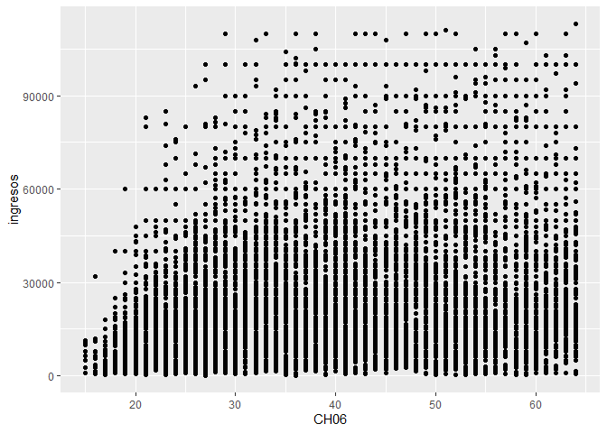

```r
ggplot(subset(eph_2_20, eph_2_20$CH06>14 & eph_2_20$CH06<65), aes(x=CH06, y=ingresos))+geom_point()
```

Puede agregarse una transparencia que muestre las zonas de mayor concentración de puntos

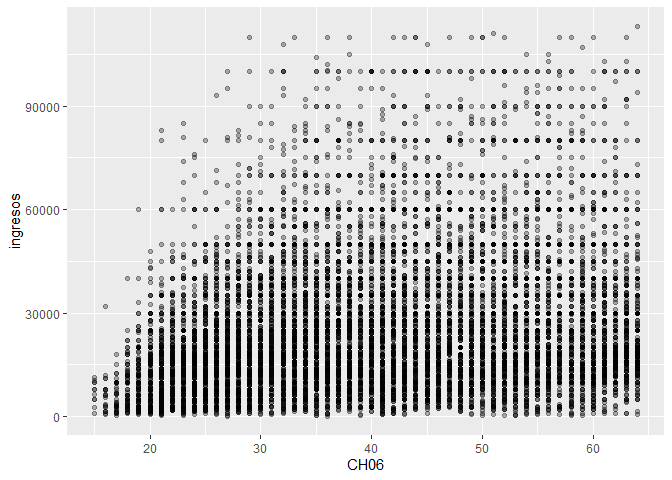

```r
ggplot(subset(eph_2_20, eph_2_20$CH06>14 & eph_2_20$CH06<65), aes(x=CH06, y=ingresos))+geom_point(alpha=.3)
```

Pero aun así la distribución es poco clara. La línea de tendencia señala mejor el modo en que sucede la relación

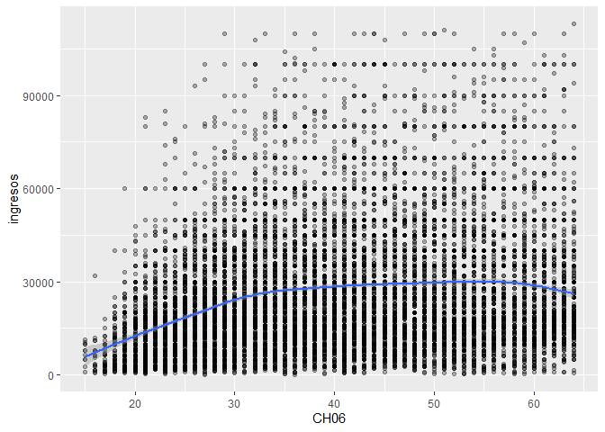

```r
ggplot(subset(eph_2_20, eph_2_20$CH06>14 & eph_2_20$CH06<65), aes(x=CH06, y=ingresos))+geom_point(alpha=.3)+geom_smooth()
```

Para reducir el volumen de información, extraemos una muestra de 100 observaciones y construimos el diagrama de dispersión sobre ella (en el rango de edades de 15 a 64 años)

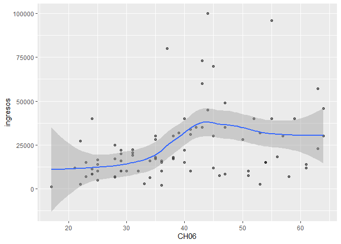

```r
set.seed(13)
muestra_eph<-eph_2_20[sample(nrow(eph_2_20), 100), ]

ggplot(subset(muestra_eph, muestra_eph$CH06>14 & muestra_eph$CH06<65), aes(x=CH06, y=ingresos))+geom_point(alpha=.5)+geom_smooth()
```

La banda alrededor de la línea de tendencia es el error, calculado localmente. Se la puede eliminar en el argumento de la capa de la línea

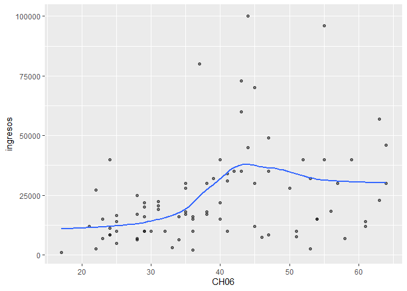

```r
ggplot(subset(muestra_eph, muestra_eph$CH06>14 & muestra_eph$CH06<65), aes(x=CH06, y=ingresos))+geom_point(alpha=.5)+geom_smooth(se=FALSE)
```

Ahora se puede mejorar el aspecto del gráfico

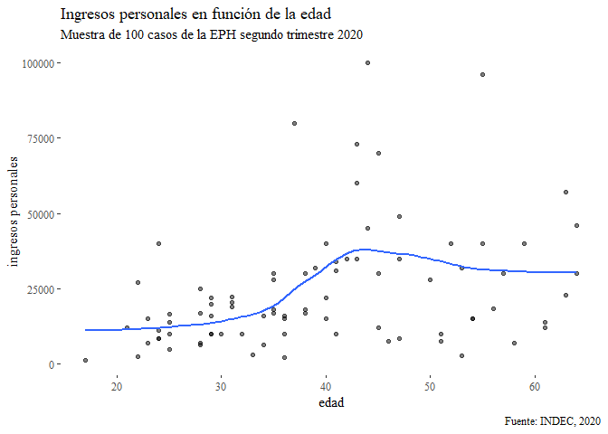

```r
ggplot(subset(muestra_eph, muestra_eph$CH06>14 & muestra_eph$CH06<65), aes(x=CH06, y=ingresos))+geom_point(alpha=.5)+geom_smooth(se=FALSE)+
  labs(title = "Ingresos personales en función de la edad",
       subtitle = "Muestra de 100 casos de la EPH segundo trimestre 2020", caption = "Fuente: INDEC, 2020")+xlab("edad")+ylab("ingresos personales")+theme_tufte()
```

Si se limita la muestra solo a jefes y jefas de hogar y se separa por sexos, se obtiene

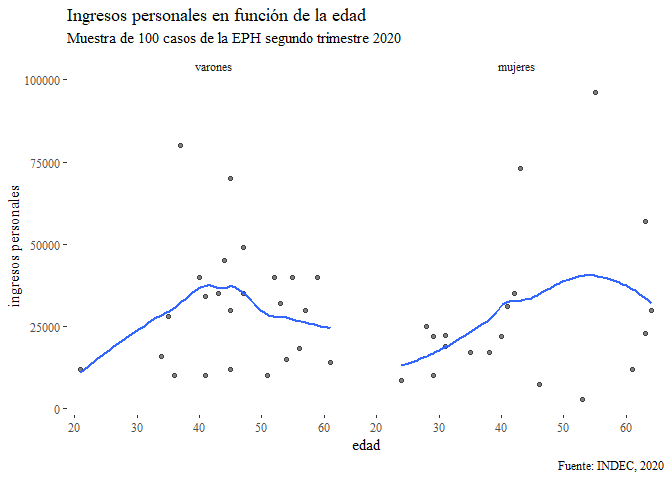

```r
ggplot(subset(muestra_eph, muestra_eph$CH06>14 & muestra_eph$CH06<65 & muestra_eph$CH03==1), aes(x=CH06, y=ingresos))+geom_point(alpha=.5)+geom_smooth(se=FALSE)+
  labs(title = "Ingresos personales en función de la edad",
       subtitle = "Muestra de 100 casos de la EPH segundo trimestre 2020", caption = "Fuente: INDEC, 2020")+xlab("edad")+ylab("ingresos personales")+theme_tufte()+facet_grid(.~sexo)
```

En lugar de “facetear”, la separación por sexos se puede hacer con colores

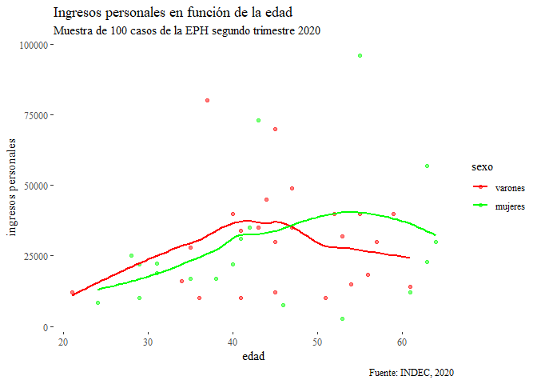

```r
ggplot(subset(muestra_eph, muestra_eph$CH06>14 & muestra_eph$CH06<65 & muestra_eph$CH03==1), aes(x=CH06, y=ingresos, col=sexo))+geom_point(alpha=.5)+geom_smooth(se=FALSE)+scale_color_manual(values=c("red", "green"))+
  labs(title = "Ingresos personales en función de la edad",
       subtitle = "Muestra de 100 casos de la EPH segundo trimestre 2020", caption = "Fuente: INDEC, 2020")+xlab("edad")+ylab("ingresos personales")+theme_tufte()
```

En este ejemplo, la instrucción *col=sexo* está en la capa base, por eso afecta tanto a *geom_point* como a *geom_smooth*. Para observar los efectos diferentes, mapeamos el sexo a la **forma** de cada punto y al **color** de la línea de tendencia.

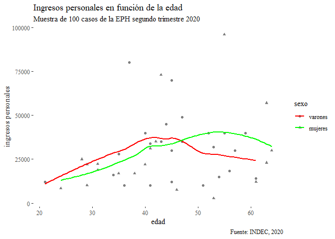

```r
ggplot(subset(muestra_eph, muestra_eph$CH06>14 & muestra_eph$CH06<65 & muestra_eph$CH03==1), aes(x=CH06, y=ingresos))+geom_point(aes(shape=sexo), alpha=.5)+geom_smooth(aes(col=sexo) , se=FALSE)+scale_color_manual(values=c("red", "green"))+
  labs(title = "Ingresos personales en función de la edad",
       subtitle = "Muestra de 100 casos de la EPH segundo trimestre 2020", caption = "Fuente: INDEC, 2020")+xlab("edad")+ylab("ingresos personales")+theme_tufte()
```

Acabamos de mapear una variable al color con el comando *col=“nombre de la variable”*, dentro de la estética, sea de la capa base o de cada elemento geométrico que se agrega. Este comando es válido para los puntos y para la línea, por eso puede ir en la capa base. Sin embargo, en el histograma, esa misma intrucción se refiere al **borde** de los rectángulos y, para solicitar que los pinte de un color asociado a las categorías de la variable (que **rellene**), la instrucción, dentro de la estética es *fill=“nombre de la variable”*. Puede parecer desconcertante, porque es el mismo efecto pero la instrucción es diferente.  
Esto tiene como consecuencia que, cuando se van a elegir los colores manualmente, en el primer caso la capa sea *scale_color_manual()* y en el segundo *scale_fill_manual()*.

## Ponderadores

Para incluir los ponderadores que permiten la expansión desde la muestra a la población, en la estética (*aes*) de la capa base, se indica que los pesos están en la variable PONDERA.

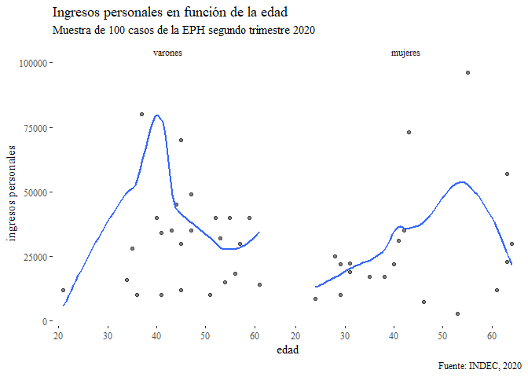

```r
ggplot(subset(muestra_eph, muestra_eph$CH06>14 & muestra_eph$CH06<65 & muestra_eph$CH03==1), aes(x=CH06, y=ingresos, weight=PONDERA))+geom_point(alpha=.5)+geom_smooth(se=FALSE)+
  labs(title = "Ingresos personales en función de la edad",
       subtitle = "Muestra de 100 casos de la EPH segundo trimestre 2020", caption = "Fuente: INDEC, 2020")+xlab("edad")+ylab("ingresos personales")+theme_tufte()+facet_grid(.~sexo)
```